# Description

## Background & Context

There is a huge demand for used cars in the Indian Market today. As sales of new cars have slowed down in the recent past, the pre-owned car market has continued to grow over the past years and is larger than the new car market now. Cars4U is a budding tech start-up that aims to find footholes in this market.

In 2018-19, while new car sales were recorded at 3.6 million units, around 4 million second-hand cars were bought and sold. There is a slowdown in new car sales and that could mean that the demand is shifting towards the pre-owned market. In fact, some car sellers replace their old cars with pre-owned cars instead of buying new ones. Unlike new cars, where price and supply are fairly deterministic and managed by OEMs (Original Equipment Manufacturer / except for dealership level discounts which come into play only in the last stage of the customer journey), used cars are very different beasts with huge uncertainty in both pricing and supply. Keeping this in mind, the pricing scheme of these used cars becomes important in order to grow in the market.

As a senior data scientist at Cars4U, you have to come up with a pricing model that can effectively predict the price of used cars and can help the business in devising profitable strategies using differential pricing. For example, if the business knows the market price, it will never sell anything below it.

## Objective

- Explore and visualize the dataset.
- Build a linear regression model to predict the prices of used cars.
- Generate a set of insights and recommendations that will help the business.

## Data Dictionary

- S.No. : Serial Number
- Name : Name of the car which includes Brand name and Model name
- Location : The location in which the car is being sold or is available for purchase Cities
- Year : Manufacturing year of the car
- Kilometers_driven : The total kilometers driven in the car by the previous owner(s) in KM.
- Fuel_Type : The type of fuel used by the car. (Petrol, Diesel, Electric, CNG, LPG)
- Transmission : The type of transmission used by the car. (Automatic / Manual)
- Owner : Type of ownership
- Mileage : The standard mileage offered by the car company in kmpl or km/kg
- Engine : The displacement volume of the engine in CC.
- Power : The maximum power of the engine in bhp.
- Seats : The number of seats in the car.
- New_Price : The price of a new car of the same model in INR Lakhs.(1 Lakh = 100, 000)
- Price : The price of the used car in INR Lakhs (1 Lakh = 100, 000)

```python
# this will help in making the Python code more structured automatically.
#!pip install nb-black
%load_ext nb_black
```

```
The nb_black extension is already loaded. To reload it, use:
  %reload_ext nb_black
```

### Loading necessary libraries

```python
import pandas as pd
import numpy as np
import matplotlib.pyplot as plt
import seaborn as sns

sns.set()

import warnings

warnings.filterwarnings("ignore")

# Removes the limit for the number of displayed columns
pd.set_option("display.max_columns", None)
# Sets the limit for the number of displayed rows
pd.set_option("display.max_rows", 200)

# To build linear model for prediction
from sklearn.linear_model import LinearRegression

# To check model performance
from sklearn.metrics import mean_squared_error, r2_score, mean_absolute_error
```

### Load the dataset

```python
data = pd.read_csv("used_cars_data.csv")

# creating a copy of the data so that original data remains unchanged
df = data.copy()
```

### Let's view a sample of the dataset.

```python
print(f"There are {df.shape[0]} rows and {df.shape[1]} columns.")  # f-string

# I'm now going to look at 10 random rows
# I'm setting the random seed via np.random.seed so that
# I get the same random results every time
np.random.seed(1)
df.sample(n=20)
```

```
There are 7253 rows and 14 columns.
```

|  | S.No. | Name | Location | Year | Kilometers_Driven | Fuel_Type | Transmission | Owner_Type | Mileage | Engine | Power | Seats | New_Price | Price |
| --- | --- | --- | --- | --- | --- | --- | --- | --- | --- | --- | --- | --- | --- | --- |
| 2397 | 2397 | Ford EcoSport 1.5 Petrol Trend | Kolkata | 2016 | 21460 | Petrol | Manual | First | 17.0 kmpl | 1497 CC | 121.36 bhp | 5.0 | 9.47 Lakh | 6.00 |
| 3777 | 3777 | Maruti Wagon R VXI 1.2 | Kochi | 2015 | 49818 | Petrol | Manual | First | 21.5 kmpl | 1197 CC | 81.80 bhp | 5.0 | 5.44 Lakh | 4.11 |
| 4425 | 4425 | Ford Endeavour 4x2 XLT | Hyderabad | 2007 | 130000 | Diesel | Manual | First | 13.1 kmpl | 2499 CC | 141 bhp | 7.0 | NaN | 6.00 |
| 3661 | 3661 | Mercedes-Benz E-Class E250 CDI Avantgrade | Coimbatore | 2016 | 39753 | Diesel | Automatic | First | 13.0 kmpl | 2143 CC | 201.1 bhp | 5.0 | NaN | 35.28 |
| 4514 | 4514 | Hyundai Xcent 1.2 Kappa AT SX Option | Kochi | 2016 | 45560 | Petrol | Automatic | First | 16.9 kmpl | 1197 CC | 82 bhp | 5.0 | NaN | 6.34 |
| 599 | 599 | Toyota Innova Crysta 2.8 ZX AT | Coimbatore | 2019 | 40674 | Diesel | Automatic | First | 11.36 kmpl | 2755 CC | 171.5 bhp | 7.0 | 28.05 Lakh | 24.82 |
| 186 | 186 | Mercedes-Benz E-Class E250 CDI Avantgrade | Bangalore | 2014 | 37382 | Diesel | Automatic | First | 13.0 kmpl | 2143 CC | 201.1 bhp | 5.0 | NaN | 32.00 |
| 305 | 305 | Audi A6 2011-2015 2.0 TDI Premium Plus | Kochi | 2014 | 61726 | Diesel | Automatic | First | 17.68 kmpl | 1968 CC | 174.33 bhp | 5.0 | NaN | 20.77 |
| 4582 | 4582 | Hyundai i20 1.2 Magna | Kolkata | 2011 | 36000 | Petrol | Manual | First | 18.5 kmpl | 1197 CC | 80 bhp | 5.0 | NaN | 2.50 |
| 5434 | 5434 | Honda WR-V Edge Edition i-VTEC S | Kochi | 2019 | 13913 | Petrol | Manual | First | 17.5 kmpl | 1199 CC | 88.7 bhp | 5.0 | 9.36 Lakh | 8.20 |
| 3042 | 3042 | Hyundai Verna 1.6 VTVT | Kolkata | 2011 | 36226 | Petrol | Manual | First | 17.01 kmpl | 1591 CC | 121.3 bhp | 5.0 | NaN | 2.95 |
| 503 | 503 | Toyota Fortuner 4x4 AT | Delhi | 2017 | 25000 | Diesel | Automatic | First | 12.55 kmpl | 2982 CC | 168.5 bhp | 7.0 | NaN | 32.00 |
| 1038 | 1038 | Land Rover Range Rover TDV8 (Diesel) | Bangalore | 2011 | 55000 | Diesel | Automatic | First | 10.2 kmpl | 4367 CC | 308 bhp | 7.0 | NaN | 67.00 |
| 4543 | 4543 | Maruti Alto K10 VXI AGS | Chennai | 2017 | 5500 | Petrol | Automatic | First | 24.07 kmpl | 998 CC | 67.1 bhp | 5.0 | NaN | 4.25 |
| 2328 | 2328 | BMW X5 xDrive 30d M Sport | Chennai | 2017 | 6500000 | Diesel | Automatic | First | 15.97 kmpl | 2993 CC | 258 bhp | 5.0 | NaN | 65.00 |
| 343 | 343 | Maruti Vitara Brezza LDi | Chennai | 2016 | 45000 | Diesel | Manual | First | 24.3 kmpl | 1248 CC | 88.5 bhp | 5.0 | 9.12 Lakh | 7.15 |
| 4172 | 4172 | Maruti Swift Dzire LXI | Delhi | 2014 | 56510 | Petrol | Manual | First | 19.1 kmpl | 1197 CC | 85.8 bhp | 5.0 | NaN | 3.90 |
| 5213 | 5213 | Toyota Innova 2.5 VX (Diesel) 8 Seater BS IV | Pune | 2015 | 77000 | Diesel | Manual | First | 12.99 kmpl | 2494 CC | 100 bhp | 8.0 | NaN | 12.50 |
| 3353 | 3353 | Hyundai Xcent 1.2 Kappa AT SX Option | Chennai | 2015 | 59800 | Petrol | Automatic | First | 16.9 kmpl | 1197 CC | 82 bhp | 5.0 | NaN | 5.80 |
| 2982 | 2982 | Hyundai Creta 1.6 SX Plus Petrol Automatic | Coimbatore | 2018 | 32807 | Petrol | Automatic | First | 13.0 kmpl | 1591 CC | 121.3 bhp | 5.0 | NaN | 14.76 |

- The *Mileage*, *Engine*, *Power*, *New_Price* are represented as strings but that we really will want to be numeric.
- The *Name* column have a vehicle name and model number mashed together.
- There are lot of missing values in New_Price columns.

### Let's check for duplicate values in the data

```python
df.duplicated().sum()
```

```
0
```

### Let's check the columns in the data.

```python
print(df.columns)
```

```
Index(['S.No.', 'Name', 'Location', 'Year', 'Kilometers_Driven', 'Fuel_Type',
       'Transmission', 'Owner_Type', 'Mileage', 'Engine', 'Power', 'Seats',
       'New_Price', 'Price'],
      dtype='object')
```

### Let's check the data types of the columns in the dataset.

```python
df.info()
```

```
<class 'pandas.core.frame.DataFrame'>
RangeIndex: 7253 entries, 0 to 7252
Data columns (total 14 columns):
 #   Column             Non-Null Count  Dtype
---  ------             --------------  -----
 0   S.No.              7253 non-null   int64
 1   Name               7253 non-null   object
 2   Location           7253 non-null   object
 3   Year               7253 non-null   int64
 4   Kilometers_Driven  7253 non-null   int64
 5   Fuel_Type          7253 non-null   object
 6   Transmission       7253 non-null   object
 7   Owner_Type         7253 non-null   object
 8   Mileage            7251 non-null   object
 9   Engine             7207 non-null   object
 10  Power              7207 non-null   object
 11  Seats              7200 non-null   float64
 12  New_Price          1006 non-null   object
 13  Price              6019 non-null   float64
dtypes: float64(2), int64(3), object(9)
memory usage: 793.4+ KB
```

- There are many numeric (*float* and *int* type) and string (*object* type) columns in the data.
- Dependent variable is the Price of an car, which is of *float* type.

### Let's check for missing values in the data.

```python
df.isnull().sum().sort_values(ascending=False)
```

```
New_Price            6247
Price                1234
Seats                  53
Engine                 46
Power                  46
Mileage                 2
S.No.                   0
Name                    0
Location                0
Year                    0
Kilometers_Driven       0
Fuel_Type               0
Transmission            0
Owner_Type              0
dtype: int64
```

- There are missing values in *Mileage*, *Engine*, *Power*, *Seats*, *New_Price*, *Price* columns.

### Summary of the dataset

```python
df.describe(include="all").T
```

|  | count | unique | top | freq | mean | std | min | 25% | 50% | 75% | max |
| --- | --- | --- | --- | --- | --- | --- | --- | --- | --- | --- | --- |
| S.No. | 7253.0 | NaN | NaN | NaN | 3626.0 | 2093.905084 | 0.0 | 1813.0 | 3626.0 | 5439.0 | 7252.0 |
| Name | 7253 | 2041 | Mahindra XUV500 W8 2WD | 55 | NaN | NaN | NaN | NaN | NaN | NaN | NaN |
| Location | 7253 | 11 | Mumbai | 949 | NaN | NaN | NaN | NaN | NaN | NaN | NaN |
| Year | 7253.0 | NaN | NaN | NaN | 2013.365366 | 3.254421 | 1996.0 | 2011.0 | 2014.0 | 2016.0 | 2019.0 |
| Kilometers_Driven | 7253.0 | NaN | NaN | NaN | 58699.063146 | 84427.720583 | 171.0 | 34000.0 | 53416.0 | 73000.0 | 6500000.0 |
| Fuel_Type | 7253 | 5 | Diesel | 3852 | NaN | NaN | NaN | NaN | NaN | NaN | NaN |
| Transmission | 7253 | 2 | Manual | 5204 | NaN | NaN | NaN | NaN | NaN | NaN | NaN |
| Owner_Type | 7253 | 4 | First | 5952 | NaN | NaN | NaN | NaN | NaN | NaN | NaN |
| Mileage | 7251 | 450 | 17.0 kmpl | 207 | NaN | NaN | NaN | NaN | NaN | NaN | NaN |
| Engine | 7207 | 150 | 1197 CC | 732 | NaN | NaN | NaN | NaN | NaN | NaN | NaN |
| Power | 7207 | 386 | 74 bhp | 280 | NaN | NaN | NaN | NaN | NaN | NaN | NaN |
| Seats | 7200.0 | NaN | NaN | NaN | 5.279722 | 0.81166 | 0.0 | 5.0 | 5.0 | 5.0 | 10.0 |
| New_Price | 1006 | 625 | 63.71 Lakh | 6 | NaN | NaN | NaN | NaN | NaN | NaN | NaN |
| Price | 6019.0 | NaN | NaN | NaN | 9.479468 | 11.187917 | 0.44 | 3.5 | 5.64 | 9.95 | 160.0 |

- Mumbai city is the most popular city for used car market.
- *Manual* and *Diesel* car is popular used car.

## Processing columns

Turn many of these into numeric columns, to get summary statistics and start getting a sense of the distributions of these variables and how they relate to each other.

### Columns containing amounts

There are some columns that represent money amounts. Some values ends with `Lakh`. First I want to detect which columns fit this pattern, and then I'll turn these into numbers.

```python
# this loop prints the names of the columns where there is
# at least one entry beginning the character 'Lakh' or Cr
money_cols = []
for colname in df.columns[
    df.dtypes == "object"
]:  # only need to consider string columns
    if (df[colname].str.endswith("Lakh").any()) or (
        df[colname].str.startswith("cr").any()
    ):  # using `.str` so I can use an element-wise string method
        money_cols.append(colname)
print(money_cols)
```

```
['New_Price']
```

```python
# Append Price column to the list for any conversion.
money_cols.append("Price")
print(money_cols)
```

```
['New_Price', 'Price']
```

```python
def income_to_num(income_val):
    """This function takes in a string representing a price in Rs
    and converts it to a number. For example, '26 Laks' becomes 2600000.
    If the input is already numeric, which probably means it's NaN,
    this function just returns np.nan."""
    if isinstance(income_val, str):  # checks if `income_val` is a string
        multiplier = 1
        if income_val.endswith("Lakh"):
            multiplier = 100000
        elif income_val.endswith("Cr"):
            multiplier = 10000000
        return float(income_val.replace("Lakh", "").replace("Cr", "")) * multiplier
    elif isinstance(income_val, float):  # checks if `income_val` is a float
        multiplier = 100000
        return income_val * multiplier
    else:  # this happens when the current income is np.nan
        return np.nan


# Added a new  flattend column.
for colname in money_cols:
    df[colname + "_Flat"] = df[colname].apply(income_to_num)

df[money_cols].head()
```

|  | New_Price | Price |
| --- | --- | --- |
| 0 | NaN | 1.75 |
| 1 | NaN | 12.50 |
| 2 | 8.61 Lakh | 4.50 |
| 3 | NaN | 6.00 |
| 4 | NaN | 17.74 |

```python
# Flattening Mileage features by removing 'kmpl' and 'km/kg' from data points.
df["Mileage_Flat"] = df["Mileage"].apply(
    lambda mi: float(str(mi).replace("kmpl", "").replace("km/kg", ""))
)
```

```python
# Flattening Engine features by cleaning 'CC' from the data.
df["Engine_Flat"] = df["Engine"].apply(
    lambda mi: float(str(mi).replace("CC", "")) if isinstance(mi, str) else np.NAN
)
```

```python
# Flattening Power features by cleaning 'bhp' and other undesirales from the data points.
def power_to_num(power_val):
    """This function takes in a string representing a salary in Euros
    and converts it to a number. For example, '€220K' becomes 220000.
    If the input is already numeric, which probably means it's NaN,
    this function just returns np.nan."""
    if isinstance(power_val, str):  # checks if `income_val` is a string
        if power_val.startswith("null"):
            return np.nan
        elif power_val.endswith("bhp"):
            return float(power_val.replace("bhp", ""))
        else:
            return np.nan
    else:  # this happens when the current income is np.nan
        return np.nan


df["Power_Flat"] = df["Power"].apply(power_to_num)
```

```python
# Splitting Name into 3 parts - Make, Model and Editoin. (Honda, Civic, sports LX)
df[["Make_Flat", "Model_Flat", "Edition_Flat"]] = df["Name"].str.split(
    " ", 2, expand=True
)
```

```python
# Dropping original columns that are cleansed into "_Flat" column
df.drop(
    ["Name", "Mileage", "Engine", "Power", "New_Price", "Price"], axis=1, inplace=True
)
```

```python
df.info()
```

```
<class 'pandas.core.frame.DataFrame'>
RangeIndex: 7253 entries, 0 to 7252
Data columns (total 16 columns):
 #   Column             Non-Null Count  Dtype
---  ------             --------------  -----
 0   S.No.              7253 non-null   int64
 1   Location           7253 non-null   object
 2   Year               7253 non-null   int64
 3   Kilometers_Driven  7253 non-null   int64
 4   Fuel_Type          7253 non-null   object
 5   Transmission       7253 non-null   object
 6   Owner_Type         7253 non-null   object
 7   Seats              7200 non-null   float64
 8   New_Price_Flat     1006 non-null   float64
 9   Price_Flat         6019 non-null   float64
 10  Mileage_Flat       7251 non-null   float64
 11  Engine_Flat        7207 non-null   float64
 12  Power_Flat         7078 non-null   float64
 13  Make_Flat          7253 non-null   object
 14  Model_Flat         7253 non-null   object
 15  Edition_Flat       7252 non-null   object
dtypes: float64(6), int64(3), object(7)
memory usage: 906.8+ KB
```

- Newly flattened columns New_Price, Price, Mileage, Engine and Power columns are float for ease of use in the model.

```python
# Rename flattened column.

df.rename(
    columns={
        "New_Price_Flat": "New_Price",
        "Price_Flat": "Price",
        "Mileage_Flat": "Mileage",
        "Engine_Flat": "Engine",
        "Power_Flat": "Power",
        "Make_Flat": "Make",
        "Model_Flat": "Model",
        "Edition_Flat": "Edition",
    },
    inplace=True,
)
```

```python
df.info()
```

```
<class 'pandas.core.frame.DataFrame'>
RangeIndex: 7253 entries, 0 to 7252
Data columns (total 16 columns):
 #   Column             Non-Null Count  Dtype
---  ------             --------------  -----
 0   S.No.              7253 non-null   int64
 1   Location           7253 non-null   object
 2   Year               7253 non-null   int64
 3   Kilometers_Driven  7253 non-null   int64
 4   Fuel_Type          7253 non-null   object
 5   Transmission       7253 non-null   object
 6   Owner_Type         7253 non-null   object
 7   Seats              7200 non-null   float64
 8   New_Price          1006 non-null   float64
 9   Price              6019 non-null   float64
 10  Mileage            7251 non-null   float64
 11  Engine             7207 non-null   float64
 12  Power              7078 non-null   float64
 13  Make               7253 non-null   object
 14  Model              7253 non-null   object
 15  Edition            7252 non-null   object
dtypes: float64(6), int64(3), object(7)
memory usage: 906.8+ KB
```

```python
df.sample(n=20)
```

|  | S.No. | Location | Year | Kilometers_Driven | Fuel_Type | Transmission | Owner_Type | Seats | New_Price | Price | Mileage | Engine | Power | Make | Model | Edition |
| --- | --- | --- | --- | --- | --- | --- | --- | --- | --- | --- | --- | --- | --- | --- | --- | --- |
| 2245 | 2245 | Mumbai | 2015 | 55000 | Petrol | Manual | First | 5.0 | 588000.0 | 310000.0 | 21.50 | 1197.0 | 81.80 | Maruti | Wagon | R VXI 1.2 |
| 6407 | 6407 | Kochi | 2017 | 62889 | Petrol | Manual | First | 5.0 | NaN | NaN | 20.40 | 1197.0 | 81.80 | Maruti | Swift | LXI Option |
| 1226 | 1226 | Delhi | 2017 | 21000 | Petrol | Automatic | First | 5.0 | 2325000.0 | 1800000.0 | 14.28 | 1798.0 | 138.03 | Toyota | Corolla | Altis 1.8 VL CVT |
| 533 | 533 | Mumbai | 2010 | 69000 | Petrol | Automatic | Second | 5.0 | NaN | 285000.0 | 16.80 | 1497.0 | 118.00 | Honda | City | 1.5 V AT |
| 6330 | 6330 | Kolkata | 2015 | 33000 | Petrol | Manual | First | 5.0 | NaN | NaN | 18.60 | 1197.0 | 81.83 | Hyundai | i20 | Asta 1.2 |
| 5931 | 5931 | Mumbai | 2012 | 52500 | Petrol | Manual | Second | 7.0 | NaN | 525000.0 | 16.02 | 1373.0 | 93.70 | Maruti | Ertiga | VXI |
| 2784 | 2784 | Hyderabad | 2011 | 86732 | Diesel | Manual | First | 5.0 | NaN | 360000.0 | 23.08 | 1461.0 | 63.10 | Nissan | Micra | Diesel XV |
| 5180 | 5180 | Bangalore | 2009 | 75000 | Petrol | Automatic | Second | 5.0 | NaN | 495000.0 | 13.70 | 1798.0 | 157.75 | Skoda | Superb | Elegance 1.8 TSI AT |
| 2722 | 2722 | Kochi | 2018 | 31426 | Diesel | Manual | First | 5.0 | 972000.0 | 790000.0 | 21.66 | 1498.0 | 108.62 | Volkswagen | Ameo | 1.5 TDI Highline |
| 5322 | 5322 | Ahmedabad | 2016 | 30000 | Diesel | Manual | First | 5.0 | NaN | 550000.0 | 24.00 | 1120.0 | 70.00 | Hyundai | Grand | i10 CRDi Sportz |
| 1983 | 1983 | Chennai | 2014 | 41123 | Petrol | Manual | First | 5.0 | NaN | 340000.0 | 23.10 | 998.0 | 67.04 | Maruti | Celerio | VXI |
| 4808 | 4808 | Pune | 2012 | 94868 | Diesel | Manual | First | 5.0 | NaN | 450000.0 | 22.90 | 1248.0 | 74.00 | Maruti | Swift | VDI |
| 724 | 724 | Mumbai | 2015 | 19000 | Petrol | Manual | First | 5.0 | NaN | 525000.0 | 20.85 | 1197.0 | 83.14 | Maruti | Swift | Dzire VXI |
| 6221 | 6221 | Kolkata | 2014 | 12000 | Diesel | Automatic | First | 5.0 | NaN | NaN | 14.74 | 2993.0 | 270.90 | Jaguar | XF | Diesel |
| 1247 | 1247 | Kochi | 2017 | 34613 | Diesel | Manual | First | 5.0 | 792000.0 | 624000.0 | 28.40 | 1248.0 | 74.00 | Maruti | Swift | VDI |
| 2996 | 2996 | Pune | 2007 | 93000 | Petrol | Automatic | Second | 5.0 | NaN | 260000.0 | 12.90 | 1799.0 | 130.00 | Honda | Civic | 2006-2010 1.8 S AT |
| 4883 | 4883 | Coimbatore | 2014 | 31446 | Petrol | Manual | First | 5.0 | NaN | 466000.0 | 20.36 | 1197.0 | 78.90 | Hyundai | i10 | Sportz |
| 890 | 890 | Bangalore | 2014 | 25789 | Diesel | Manual | Second | 5.0 | NaN | 685000.0 | 23.40 | 1248.0 | 74.00 | Maruti | Swift | Dzire ZDI |
| 5815 | 5815 | Kochi | 2018 | 37160 | Diesel | Manual | First | 5.0 | NaN | 946000.0 | 22.77 | 1498.0 | 98.59 | Ford | EcoSport | 1.5 TDCi Titanium |
| 5320 | 5320 | Mumbai | 2016 | 7523 | Petrol | Manual | First | 5.0 | NaN | 615000.0 | 16.20 | 1199.0 | 74.00 | Volkswagen | Polo | 1.2 MPI Highline |

- Price, New_price, Mileage, Power and Engine columns are cleansed.
- Name column is broken into Make, Model and edition.

```python
df.describe(include="all").T
```

|  | count | unique | top | freq | mean | std | min | 25% | 50% | 75% | max |
| --- | --- | --- | --- | --- | --- | --- | --- | --- | --- | --- | --- |
| S.No. | 7253.0 | NaN | NaN | NaN | 3626.0 | 2093.905084 | 0.0 | 1813.0 | 3626.0 | 5439.0 | 7252.0 |
| Location | 7253 | 11 | Mumbai | 949 | NaN | NaN | NaN | NaN | NaN | NaN | NaN |
| Year | 7253.0 | NaN | NaN | NaN | 2013.365366 | 3.254421 | 1996.0 | 2011.0 | 2014.0 | 2016.0 | 2019.0 |
| Kilometers_Driven | 7253.0 | NaN | NaN | NaN | 58699.063146 | 84427.720583 | 171.0 | 34000.0 | 53416.0 | 73000.0 | 6500000.0 |
| Fuel_Type | 7253 | 5 | Diesel | 3852 | NaN | NaN | NaN | NaN | NaN | NaN | NaN |
| Transmission | 7253 | 2 | Manual | 5204 | NaN | NaN | NaN | NaN | NaN | NaN | NaN |
| Owner_Type | 7253 | 4 | First | 5952 | NaN | NaN | NaN | NaN | NaN | NaN | NaN |
| Seats | 7200.0 | NaN | NaN | NaN | 5.279722 | 0.81166 | 0.0 | 5.0 | 5.0 | 5.0 | 10.0 |
| New_Price | 1006.0 | NaN | NaN | NaN | 2277969.184891 | 2775934.363434 | 391000.0 | 788500.0 | 1157000.0 | 2604250.0 | 37500000.0 |
| Price | 6019.0 | NaN | NaN | NaN | 947946.835022 | 1118791.711246 | 44000.0 | 350000.0 | 564000.0 | 995000.0 | 16000000.0 |
| Mileage | 7251.0 | NaN | NaN | NaN | 18.14158 | 4.562197 | 0.0 | 15.17 | 18.16 | 21.1 | 33.54 |
| Engine | 7207.0 | NaN | NaN | NaN | 1616.57347 | 595.285137 | 72.0 | 1198.0 | 1493.0 | 1968.0 | 5998.0 |
| Power | 7078.0 | NaN | NaN | NaN | 112.765214 | 53.493553 | 34.2 | 75.0 | 94.0 | 138.1 | 616.0 |
| Make | 7253 | 33 | Maruti | 1444 | NaN | NaN | NaN | NaN | NaN | NaN | NaN |
| Model | 7253 | 219 | Swift | 418 | NaN | NaN | NaN | NaN | NaN | NaN | NaN |
| Edition | 7252 | 1893 | VDI | 88 | NaN | NaN | NaN | NaN | NaN | NaN | NaN |

- Maruti is best selling brand in used car category.

```python
df.isnull().sum().sort_values(ascending=False)
```

```
New_Price            6247
Price                1234
Power                 175
Seats                  53
Engine                 46
Mileage                 2
Edition                 1
S.No.                   0
Location                0
Year                    0
Kilometers_Driven       0
Fuel_Type               0
Transmission            0
Owner_Type              0
Make                    0
Model                   0
dtype: int64
```

- Significant values in column New_Price is missing. It has to be dealt with.

### We will drop the missing values in *price* column as it is the target variable.

```python
# drop null values in Price column as this is target variable.
df.dropna(subset=["Price"], inplace=True)
```

```python
df.isnull().sum().sort_values(ascending=False)
```

```
New_Price            5195
Power                 143
Seats                  42
Engine                 36
Mileage                 2
S.No.                   0
Location                0
Year                    0
Kilometers_Driven       0
Fuel_Type               0
Transmission            0
Owner_Type              0
Price                   0
Make                    0
Model                   0
Edition                 0
dtype: int64
```

```python
def missing_check(df1):
    df1.isnull().sum().sort_values(ascending=False)
    total = (
        df1.isnull().sum().sort_values(ascending=False)
    )  # total number of null values
    percent = (df1.isnull().sum() / df1.isnull().count()).sort_values(
        ascending=False
    )  # percentage of values that are null
    missing_data = pd.concat(
        [total, percent], axis=1, keys=["Total", "Percent"]
    )  # putting the above two together
    return missing_data  # return the dataframe


missing_check(df)
```

|  | Total | Percent |
| --- | --- | --- |
| New_Price | 5195 | 0.863100 |
| Power | 143 | 0.023758 |
| Seats | 42 | 0.006978 |
| Engine | 36 | 0.005981 |
| Mileage | 2 | 0.000332 |
| S.No. | 0 | 0.000000 |
| Location | 0 | 0.000000 |
| Year | 0 | 0.000000 |
| Kilometers_Driven | 0 | 0.000000 |
| Fuel_Type | 0 | 0.000000 |
| Transmission | 0 | 0.000000 |
| Owner_Type | 0 | 0.000000 |
| Price | 0 | 0.000000 |
| Make | 0 | 0.000000 |
| Model | 0 | 0.000000 |
| Edition | 0 | 0.000000 |

- Around 86% of New_price has null values.

```python
# Checking rows with missing values.
num_missing = df.isnull().sum(axis=1)
num_missing.value_counts()
```

```
1    5050
0     823
2     106
4      36
3       4
dtype: int64
```

```python
df[num_missing == 2].sample(n=20)
```

|  | S.No. | Location | Year | Kilometers_Driven | Fuel_Type | Transmission | Owner_Type | Seats | New_Price | Price | Mileage | Engine | Power | Make | Model | Edition |
| --- | --- | --- | --- | --- | --- | --- | --- | --- | --- | --- | --- | --- | --- | --- | --- | --- |
| 227 | 227 | Delhi | 2013 | 47000 | Diesel | Manual | First | 5.0 | NaN | 410000.0 | 17.80 | 1248.0 | NaN | Maruti | Swift | VDI BSIV |
| 748 | 748 | Hyderabad | 2007 | 71297 | Petrol | Manual | First | 5.0 | NaN | 220000.0 | 17.00 | 1086.0 | NaN | Hyundai | Santro | Xing XO |
| 3628 | 3628 | Coimbatore | 2016 | 70478 | Diesel | Manual | First | 5.0 | NaN | 686000.0 | 17.80 | 1248.0 | NaN | Maruti | Swift | VDI BSIV W ABS |
| 4080 | 4080 | Mumbai | 2011 | 74000 | Diesel | Manual | First | 5.0 | NaN | 360000.0 | 23.59 | 1364.0 | NaN | Toyota | Etios | Liva GD |
| 2343 | 2343 | Hyderabad | 2006 | 74483 | Petrol | Automatic | First | 5.0 | NaN | 230000.0 | 0.00 | 999.0 | NaN | Hyundai | Santro | AT |
| 4077 | 4077 | Kochi | 2006 | 70362 | Petrol | Manual | Second | 5.0 | NaN | 181000.0 | 15.40 | 1590.0 | NaN | Maruti | Baleno | LXI - BSIII |
| 4709 | 4709 | Hyderabad | 1998 | 104000 | Petrol | Manual | Second | 5.0 | NaN | 85000.0 | 15.00 | 970.0 | NaN | Maruti | 1000 | AC |
| 5925 | 5925 | Pune | 2010 | 85000 | Petrol | Manual | First | 5.0 | NaN | 285000.0 | 17.50 | 1798.0 | NaN | Skoda | Laura | Classic 1.8 TSI |
| 3669 | 3669 | Hyderabad | 2007 | 57309 | Petrol | Manual | First | 5.0 | NaN | 210000.0 | 17.00 | 1086.0 | NaN | Hyundai | Santro | Xing XO |
| 1271 | 1271 | Jaipur | 2009 | 89000 | Petrol | Manual | Second | 5.0 | NaN | 160000.0 | 0.00 | 999.0 | NaN | Hyundai | Santro | GLS I - Euro II |
| 2579 | 2579 | Mumbai | 2006 | 50888 | Petrol | Manual | First | 5.0 | NaN | 115000.0 | 17.00 | 1086.0 | NaN | Hyundai | Santro | Xing XG eRLX Euro III |
| 5533 | 5533 | Pune | 2007 | 72000 | Petrol | Manual | Second | 5.0 | NaN | 111000.0 | 17.00 | 1086.0 | NaN | Hyundai | Santro | Xing XO eRLX Euro II |
| 934 | 934 | Kolkata | 2012 | 60000 | Diesel | Manual | First | 5.0 | NaN | 295000.0 | 23.59 | 1364.0 | NaN | Toyota | Etios | GD |
| 2891 | 2891 | Bangalore | 2013 | 58291 | Diesel | Manual | First | 5.0 | NaN | 500000.0 | 17.80 | 1248.0 | NaN | Maruti | Swift | VDI BSIV |
| 3439 | 3439 | Pune | 2010 | 63600 | Diesel | Manual | Second | 5.0 | NaN | 310000.0 | 17.80 | 1248.0 | NaN | Maruti | Swift | VDI BSIV W ABS |
| 5943 | 5943 | Chennai | 2002 | 75000 | Diesel | Manual | First | 6.0 | NaN | 170000.0 | 0.00 | 2112.0 | NaN | Mahindra | Jeep | MM 540 DP |
| 245 | 245 | Mumbai | 2007 | 72000 | Petrol | Manual | Third | 5.0 | NaN | 95000.0 | 17.00 | 1086.0 | NaN | Hyundai | Santro | Xing XO eRLX Euro II |
| 3247 | 3247 | Chennai | 2011 | 79000 | Diesel | Manual | First | 5.0 | NaN | 467000.0 | 23.59 | 1364.0 | NaN | Toyota | Etios | GD |
| 5119 | 5119 | Kolkata | 2008 | 45500 | Petrol | Manual | Second | 5.0 | NaN | 117000.0 | 0.00 | 1086.0 | NaN | Hyundai | Santro | Xing XP |
| 3033 | 3033 | Jaipur | 2005 | 120000 | Petrol | Manual | First | 5.0 | NaN | 115000.0 | 0.00 | 1086.0 | NaN | Hyundai | Santro | Xing XP |

```python
# Dropping all the rows that has null values in New_price.

df.dropna(subset=["New_Price"], inplace=True)
df.dropna(inplace=True)
```

```python
df.isnull().sum().sort_values(ascending=False)
```

```
S.No.                0
Location             0
Year                 0
Kilometers_Driven    0
Fuel_Type            0
Transmission         0
Owner_Type           0
Seats                0
New_Price            0
Price                0
Mileage              0
Engine               0
Power                0
Make                 0
Model                0
Edition              0
dtype: int64
```

```python
df.info()
```

```
<class 'pandas.core.frame.DataFrame'>
Int64Index: 823 entries, 2 to 6014
Data columns (total 16 columns):
 #   Column             Non-Null Count  Dtype
---  ------             --------------  -----
 0   S.No.              823 non-null    int64
 1   Location           823 non-null    object
 2   Year               823 non-null    int64
 3   Kilometers_Driven  823 non-null    int64
 4   Fuel_Type          823 non-null    object
 5   Transmission       823 non-null    object
 6   Owner_Type         823 non-null    object
 7   Seats              823 non-null    float64
 8   New_Price          823 non-null    float64
 9   Price              823 non-null    float64
 10  Mileage            823 non-null    float64
 11  Engine             823 non-null    float64
 12  Power              823 non-null    float64
 13  Make               823 non-null    object
 14  Model              823 non-null    object
 15  Edition            823 non-null    object
dtypes: float64(6), int64(3), object(7)
memory usage: 109.3+ KB
```

```python
# All the null values are dealt with.
df[df.isna().any(axis=1)]
```

|  | S.No. | Location | Year | Kilometers_Driven | Fuel_Type | Transmission | Owner_Type | Seats | New_Price | Price | Mileage | Engine | Power | Make | Model | Edition |
| --- | --- | --- | --- | --- | --- | --- | --- | --- | --- | --- | --- | --- | --- | --- | --- | --- |

## Let's visualize the data

### Univariate Analysis

```python
# This functions helps to perfom univariate analysis to study column central tendency and dispersion.


def plot_box_hist(column):
    """Boxplot and histogram combined
    feature: 1-d feature array
    """
    fig, (axis_box, axis_hist) = plt.subplots(
        nrows=2,
        sharex=True,
        gridspec_kw={"height_ratios": (0.3, 0.7)},
        figsize=(15, 5),
    )
    sns.boxplot(column, ax=axis_box, showmeans=True, color="violet")
    sns.distplot(column, ax=axis_hist, kde=True)
    # Add mean to the histogram
    axis_hist.axvline(np.mean(column), color="green", linestyle="--")
    # Add median to the histogram
    axis_hist.axvline(np.median(column), color="red", linestyle="-")
    plt.show()


# This function helps to identify outlier for a given column.
# For this analysis any data points above 4 times of IQR is considers as ooutliers.


def IQR4(column, cname):
    """Gives list that is greater than
    4 times inter quartile range.
    """
    quartiles = np.quantile(column[column.notnull()], [0.25, 0.75])
    power_4iqr = 4 * (quartiles[1] - quartiles[0])
    print(f"Q1 = {quartiles[0]}, Q3 = {quartiles[1]}, 4*IQR = {power_4iqr}")
    outlier_powers = df.loc[np.abs(column - column.median()) > power_4iqr, cname]
    return outlier_powers
```

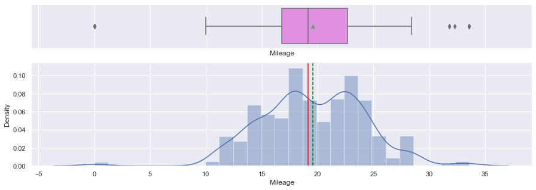

```
Q1 = 16.77, Q3 = 22.69, 4*IQR = 23.680000000000007
Series([], Name: Mileage, dtype: float64)
```

```python
plot_box_hist(df["Mileage"])

print(IQR4(df["Mileage"], "Mileage"))
```

- Though Mileage mean is around 20, most of the cars are clustered around 18 and 23 KMPL.
- No outliers.

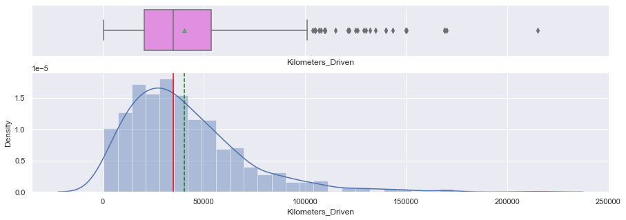

```
Q1 = 20487.5, Q3 = 53829.0, 4*IQR = 133366.0
838     215000
1717    169000
3640    169006
5254    170000
Name: Kilometers_Driven, dtype: int64
```

```python
plot_box_hist(df["Kilometers_Driven"])
print(IQR4(df["Kilometers_Driven"], "Kilometers_Driven"))
```

- There are 4 outliers in the kilometer driven column.

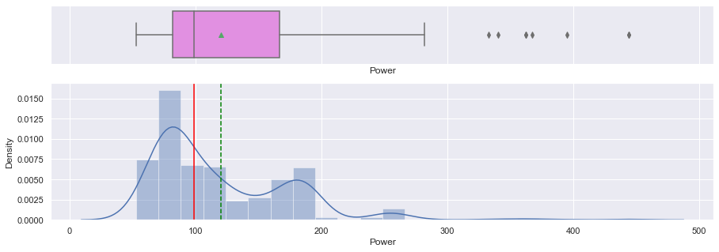

```
Q1 = 81.86, Q3 = 166.85, 4*IQR = 339.96
148     444.0
4061    444.0
Name: Power, dtype: float64
```

```python
plot_box_hist(df["Power"])
print(IQR4(df["Power"], "Power"))
```

- There are 2 outliers in the power column.

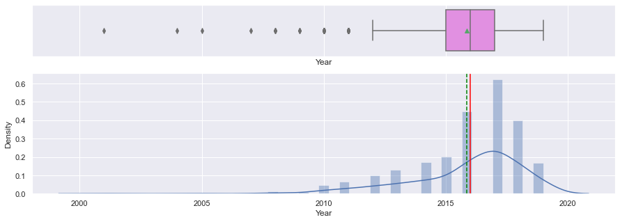

```
Q1 = 2015.0, Q3 = 2017.0, 4*IQR = 8.0
351     2005
2119    2007
4863    2001
5569    2004
Name: Year, dtype: int64
```

```python
plot_box_hist(df["Year"])
print(IQR4(df["Year"], "Year"))
```

- Year column has 4 outlier

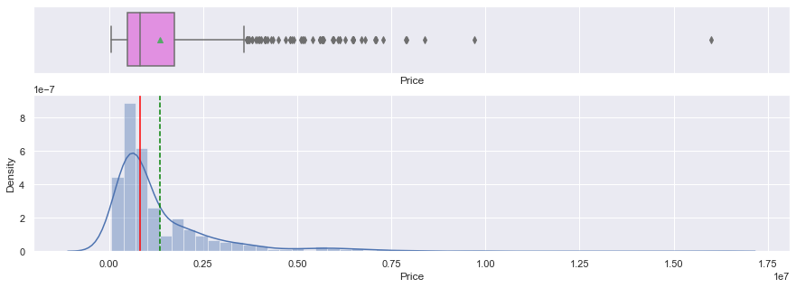

```
Q1 = 500000.0, Q3 = 1750000.0, 4*IQR = 5000000.0
4079    16000000.0
1505     9707000.0
2095     8396000.0
1885     7900000.0
2319     7880000.0
1583     7294000.0
418      7099000.0
1690     7080000.0
3752     7066000.0
5009     6800000.0
1336     6700000.0
4527     6500000.0
2808     6495000.0
1830     6487000.0
5545     6475000.0
327      6267000.0
264      6129000.0
5516     6125000.0
5118     6075000.0
941      5972000.0
3268     5965000.0
2767     5929000.0
Name: Price, dtype: float64
```

```python
plot_box_hist(df["Price"])
print(IQR4(df["Price"], "Price").sort_values(ascending=False))
```

- Price column has significant number of outliers.

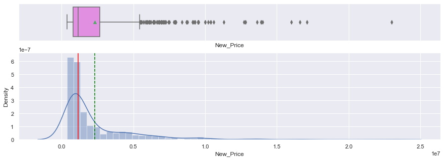

```
Q1 = 797500.0, Q3 = 2656000.0, 4*IQR = 7434000.0
4079    23000000.0
4778    17100000.0
3199    16600000.0
3752    16000000.0
2056    14000000.0
5545    13900000.0
1505    13900000.0
3132    13600000.0
4061    12800000.0
148     12800000.0
2178    12700000.0
2528    11300000.0
2095    10600000.0
1336    10400000.0
```

[output cut: 20 more lines]

```python
plot_box_hist(df["New_Price"])
print(IQR4(df["New_Price"], "New_Price").sort_values(ascending=False))
```

- Like used car Price, New proce has significant outliers. Specically index '4079'

### Cateogorical value treatment

```python
df.Fuel_Type.unique()
```

```
array(['Petrol', 'Diesel', 'CNG'], dtype=object)
```

```python
df.Owner_Type.unique()
```

```
array(['First', 'Second', 'Third'], dtype=object)
```

```python
df.Seats.unique()
```

```
array([5., 8., 7., 2., 4., 6.])
```

```python
df.Transmission.unique()
```

```
array(['Manual', 'Automatic'], dtype=object)
```

```python
df.Location.unique()
```

```
array(['Chennai', 'Mumbai', 'Kochi', 'Delhi', 'Coimbatore', 'Bangalore',
       'Pune', 'Ahmedabad', 'Kolkata', 'Hyderabad', 'Jaipur'],
      dtype=object)
```

```python
df["Fuel_Type"] = df["Fuel_Type"].astype("category")
df["Owner_Type"] = df["Owner_Type"].astype("category")
df["Seats"] = df["Seats"].astype("int")
df["Seats"] = df["Seats"].astype("category")
df["Transmission"] = df["Transmission"].astype("category")
df["Location"] = df["Location"].astype("category")
```

- Converted *fuel type*, *owner type*, *Seats*, *Transmision* and *Location* too category as these column has few unique values.

```python
df.info()
```

```
<class 'pandas.core.frame.DataFrame'>
Int64Index: 823 entries, 2 to 6014
Data columns (total 16 columns):
 #   Column             Non-Null Count  Dtype
---  ------             --------------  -----
 0   S.No.              823 non-null    int64
 1   Location           823 non-null    category
 2   Year               823 non-null    int64
 3   Kilometers_Driven  823 non-null    int64
 4   Fuel_Type          823 non-null    category
 5   Transmission       823 non-null    category
 6   Owner_Type         823 non-null    category
 7   Seats              823 non-null    category
 8   New_Price          823 non-null    float64
 9   Price              823 non-null    float64
 10  Mileage            823 non-null    float64
 11  Engine             823 non-null    float64
 12  Power              823 non-null    float64
 13  Make               823 non-null    object
 14  Model              823 non-null    object
 15  Edition            823 non-null    object
dtypes: category(5), float64(5), int64(3), object(3)
memory usage: 82.1+ KB
```

```python
# Function to create barplots that indicate percentage for each category.


def perc_on_bar(data, column):
    """
    plot
    feature: categorical feature
    the function won't work if a column is passed in hue parameter
    """

    total = len(data[column])  # length of the column
    plt.figure(figsize=(15, 5))
    plt.xticks(rotation=45)
    ax = sns.countplot(data[column], palette="Paired")
    for p in ax.patches:
        percentage = "{:.1f}%".format(
            100 * p.get_height() / total
        )  # percentage of each class of the category
        x = p.get_x() + p.get_width() / 2 - 0.05  # width of the plot
        y = p.get_y() + p.get_height()  # hieght of the plot

        ax.annotate(percentage, (x, y), size=10)  # annotate the percantage
    plt.show()  # show the plot
```

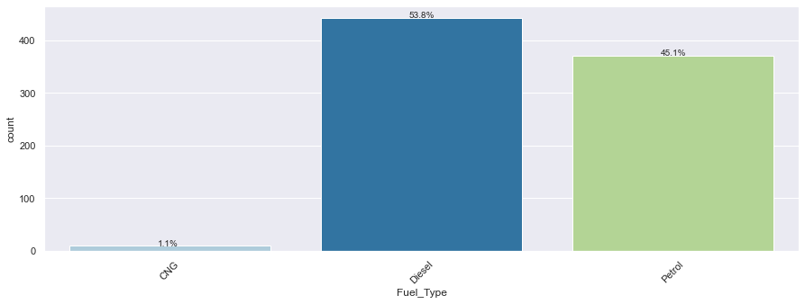

```python
perc_on_bar(df, "Fuel_Type")
```

- Most of the fuel type are either Diesel or Petrol.

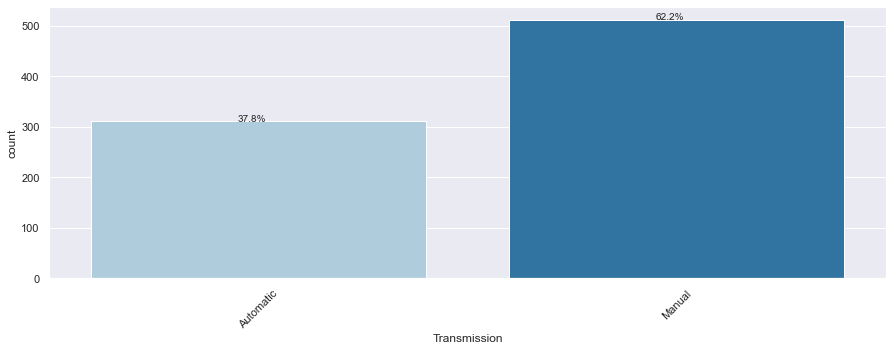

```python
perc_on_bar(df, "Transmission")
```

- Most popular transmission type is Manual.

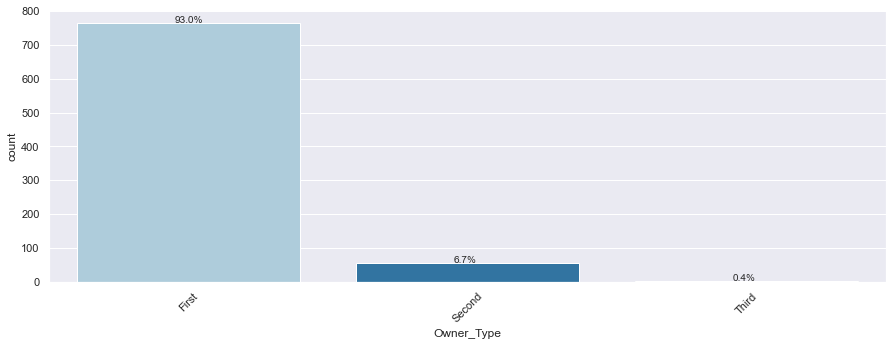

```python
perc_on_bar(df, "Owner_Type")
```

- First hand car has bulk share in the used car market.

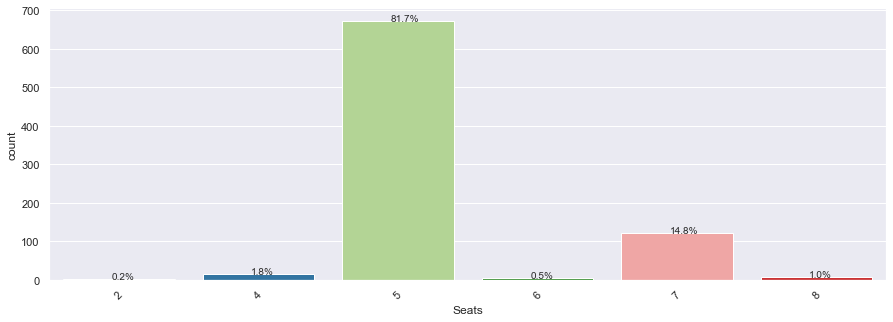

```python
perc_on_bar(df, "Seats")
```

- 5 seater is a poular in used car market.

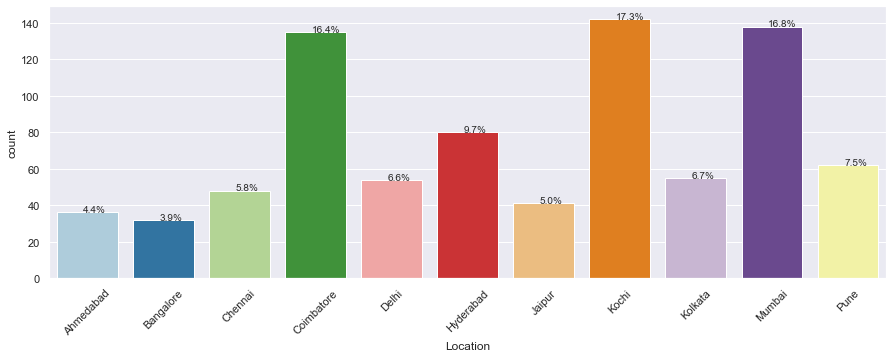

```python
perc_on_bar(df, "Location")
```

```python
df.Year.unique()
```

```
array([2011, 2016, 2018, 2014, 2012, 2017, 2019, 2015, 2013, 2008, 2005,
       2010, 2007, 2009, 2001, 2004])
```

```python
df.nlargest(30, "Price")
```

|  | S.No. | Location | Year | Kilometers_Driven | Fuel_Type | Transmission | Owner_Type | Seats | New_Price | Price | Mileage | Engine | Power | Make | Model | Edition |
| --- | --- | --- | --- | --- | --- | --- | --- | --- | --- | --- | --- | --- | --- | --- | --- | --- |
| 4079 | 4079 | Hyderabad | 2017 | 25000 | Diesel | Automatic | First | 5 | 23000000.0 | 16000000.0 | 13.33 | 2993.0 | 255.00 | Land | Rover | Range Rover 3.0 Diesel LWB Vogue |
| 1505 | 1505 | Kochi | 2019 | 26013 | Diesel | Automatic | First | 5 | 13900000.0 | 9707000.0 | 12.65 | 2993.0 | 255.00 | Land | Rover | Range Rover Sport SE |
| 2095 | 2095 | Coimbatore | 2019 | 2526 | Petrol | Automatic | First | 2 | 10600000.0 | 8396000.0 | 19.00 | 2996.0 | 362.07 | Mercedes-Benz | SLC | 43 AMG |
| 1885 | 1885 | Delhi | 2018 | 6000 | Diesel | Automatic | First | 7 | 10200000.0 | 7900000.0 | 11.00 | 2987.0 | 258.00 | Mercedes-Benz | GLS | 350d Grand Edition |
| 2319 | 2319 | Coimbatore | 2019 | 9312 | Diesel | Automatic | First | 5 | 9250000.0 | 7880000.0 | 18.00 | 2987.0 | 258.00 | Mercedes-Benz | E-Class | E 350 d |
| 1583 | 1583 | Kochi | 2019 | 6773 | Diesel | Automatic | First | 7 | 9138000.0 | 7294000.0 | 14.75 | 2967.0 | 245.00 | Audi | Q7 | 45 TDI Quattro Premium Plus |
| 418 | 418 | Coimbatore | 2018 | 22397 | Petrol | Automatic | First | 5 | 9538000.0 | 7099000.0 | 11.50 | 2996.0 | 367.00 | Mercedes-Benz | GLC | 43 AMG Coupe |
| 1690 | 1690 | Coimbatore | 2018 | 40129 | Diesel | Automatic | First | 5 | 9513000.0 | 7080000.0 | 11.57 | 2987.0 | 254.79 | Mercedes-Benz | GLE | 350d |
| 3752 | 3752 | Kochi | 2015 | 38467 | Diesel | Automatic | First | 5 | 16000000.0 | 7066000.0 | 12.65 | 2993.0 | 255.00 | Land | Rover | Range Rover Sport HSE |
| 5009 | 5009 | Pune | 2017 | 59500 | Diesel | Automatic | First | 7 | 9992000.0 | 6800000.0 | 14.75 | 2967.0 | 245.00 | Audi | Q7 | 45 TDI Quattro Technology |
| 1336 | 1336 | Mumbai | 2016 | 20002 | Diesel | Automatic | First | 7 | 10400000.0 | 6700000.0 | 14.75 | 2967.0 | 245.00 | Audi | Q7 | 45 TDI Quattro Technology |
| 4527 | 4527 | Chennai | 2016 | 29000 | Diesel | Automatic | First | 5 | 9279000.0 | 6500000.0 | 11.57 | 2987.0 | 254.79 | Mercedes-Benz | GLE | 350d |
| 2808 | 2808 | Mumbai | 2017 | 19863 | Diesel | Automatic | First | 5 | 9123000.0 | 6495000.0 | 11.57 | 2987.0 | 254.79 | Mercedes-Benz | GLE | 350d |
| 1830 | 1830 | Coimbatore | 2017 | 33552 | Diesel | Automatic | First | 5 | 9513000.0 | 6487000.0 | 11.57 | 2987.0 | 254.79 | Mercedes-Benz | GLE | 350d |
| 5545 | 5545 | Delhi | 2014 | 47000 | Diesel | Automatic | Second | 5 | 13900000.0 | 6475000.0 | 12.65 | 2993.0 | 255.00 | Land | Rover | Range Rover Sport SE |
| 327 | 327 | Coimbatore | 2017 | 97430 | Diesel | Automatic | First | 7 | 10400000.0 | 6267000.0 | 14.75 | 2967.0 | 245.00 | Audi | Q7 | 45 TDI Quattro Technology |
| 264 | 264 | Coimbatore | 2017 | 29819 | Diesel | Automatic | First | 5 | 9513000.0 | 6129000.0 | 11.57 | 2987.0 | 254.79 | Mercedes-Benz | GLE | 350d |
| 5516 | 5516 | Mumbai | 2018 | 1400 | Diesel | Automatic | First | 5 | 7055000.0 | 6125000.0 | 18.56 | 1995.0 | 190.00 | BMW | X3 | xDrive 20d Luxury Line |
| 5118 | 5118 | Bangalore | 2016 | 28541 | Diesel | Automatic | First | 5 | 9513000.0 | 6075000.0 | 11.57 | 2987.0 | 254.79 | Mercedes-Benz | GLE | 350d |
| 941 | 941 | Kochi | 2018 | 31427 | Diesel | Automatic | First | 5 | 7512000.0 | 5972000.0 | 15.68 | 1999.0 | 177.00 | Land | Rover | Range Rover Evoque 2.0 TD4 HSE Dynamic |
| 3268 | 3268 | Coimbatore | 2018 | 29277 | Diesel | Automatic | First | 5 | 9513000.0 | 5965000.0 | 11.57 | 2987.0 | 254.79 | Mercedes-Benz | GLE | 350d |
| 2767 | 2767 | Coimbatore | 2018 | 30706 | Diesel | Automatic | First | 5 | 9513000.0 | 5929000.0 | 11.57 | 2987.0 | 254.79 | Mercedes-Benz | GLE | 350d |
| 310 | 310 | Hyderabad | 2017 | 29000 | Diesel | Automatic | First | 5 | 7943000.0 | 5700000.0 | 17.90 | 2143.0 | 201.15 | Mercedes-Benz | GLE | 250d |
| 4451 | 4451 | Kochi | 2018 | 21290 | Petrol | Automatic | First | 4 | 8392000.0 | 5680000.0 | 13.00 | 4951.0 | 395.00 | Ford | Mustang | V8 |
| 2111 | 2111 | Kochi | 2017 | 25601 | Diesel | Automatic | First | 5 | 7876000.0 | 5673000.0 | 17.90 | 2143.0 | 201.15 | Mercedes-Benz | GLE | 250d |
| 2509 | 2509 | Mumbai | 2018 | 11000 | Diesel | Automatic | First | 5 | 7055000.0 | 5650000.0 | 16.10 | 1950.0 | 194.00 | Mercedes-Benz | E-Class | E 220 d |
| 5038 | 5038 | Coimbatore | 2019 | 24013 | Diesel | Automatic | First | 7 | 6922000.0 | 5614000.0 | 12.81 | 1999.0 | 148.31 | Land | Rover | Discovery Sport TD4 HSE 7S |
| 489 | 489 | Pune | 2017 | 129000 | Diesel | Automatic | First | 7 | 10000000.0 | 5600000.0 | 11.00 | 2987.0 | 258.00 | Mercedes-Benz | GLS | 350d 4MATIC |
| 802 | 802 | Mumbai | 2016 | 21000 | Diesel | Automatic | First | 5 | 7876000.0 | 5600000.0 | 17.90 | 2143.0 | 201.15 | Mercedes-Benz | GLE | 250d |
| 134 | 134 | Kolkata | 2017 | 13372 | Petrol | Automatic | First | 2 | 9504000.0 | 5400000.0 | 19.00 | 2996.0 | 362.07 | Mercedes-Benz | SLC | 43 AMG |

- Higher price cars are dominated by luxuary brands like Mercedes benz, Land Rover and Audi. No surprises here.

```python
df.nsmallest(30, "Price")
```

|  | S.No. | Location | Year | Kilometers_Driven | Fuel_Type | Transmission | Owner_Type | Seats | New_Price | Price | Mileage | Engine | Power | Make | Model | Edition |
| --- | --- | --- | --- | --- | --- | --- | --- | --- | --- | --- | --- | --- | --- | --- | --- | --- |
| 4863 | 4863 | Chennai | 2001 | 140000 | Petrol | Manual | Third | 5 | 455000.0 | 70000.0 | 20.30 | 1086.0 | 68.00 | Hyundai | Santro | D Lite |
| 2200 | 2200 | Mumbai | 2010 | 38000 | Petrol | Manual | Second | 5 | 561000.0 | 175000.0 | 22.50 | 998.0 | 67.04 | Maruti | Wagon | R VXI |
| 1313 | 1313 | Chennai | 2008 | 121097 | Diesel | Manual | Second | 5 | 1073000.0 | 190000.0 | 24.00 | 1396.0 | 88.76 | Hyundai | Verna | CRDi 1.4 E |
| 3132 | 3132 | Kochi | 2019 | 14298 | Petrol | Automatic | First | 5 | 13600000.0 | 202000.0 | 13.33 | 2995.0 | 340.00 | Porsche | Cayenne | Base |
| 351 | 351 | Jaipur | 2005 | 100000 | Petrol | Automatic | First | 5 | 2837000.0 | 205000.0 | 14.45 | 1984.0 | 227.00 | Skoda | Octavia | RS |
| 5087 | 5087 | Pune | 2014 | 17000 | Petrol | Manual | First | 5 | 448000.0 | 210000.0 | 24.07 | 998.0 | 67.10 | Maruti | Alto | K10 VXI |
| 3820 | 3820 | Chennai | 2011 | 28300 | Petrol | Manual | First | 5 | 450000.0 | 215000.0 | 24.07 | 998.0 | 67.10 | Maruti | Alto | K10 VXI |
| 5650 | 5650 | Delhi | 2016 | 126000 | Petrol | Manual | First | 7 | 443000.0 | 220000.0 | 15.10 | 1196.0 | 73.00 | Maruti | Eeco | 7 Seater Standard |
| 2746 | 2746 | Pune | 2011 | 45000 | Petrol | Manual | First | 7 | 469000.0 | 225000.0 | 15.10 | 1196.0 | 73.00 | Maruti | Eeco | 7 Seater Standard |
| 3173 | 3173 | Pune | 2012 | 150000 | Diesel | Manual | Third | 5 | 791000.0 | 225000.0 | 28.40 | 1248.0 | 73.75 | Maruti | Dzire | LDI |
| 4819 | 4819 | Kolkata | 2016 | 15000 | Petrol | Manual | First | 5 | 398000.0 | 225000.0 | 22.70 | 799.0 | 53.64 | Datsun | redi-GO | T |
| 5393 | 5393 | Pune | 2010 | 45252 | Petrol | Manual | First | 5 | 680000.0 | 225000.0 | 18.90 | 1197.0 | 81.86 | Hyundai | Grand | i10 1.2 Kappa Magna |
| 813 | 813 | Pune | 2014 | 49000 | Petrol | Manual | First | 5 | 429000.0 | 230000.0 | 24.07 | 998.0 | 67.10 | Maruti | Alto | K10 LXI |
| 2749 | 2749 | Mumbai | 2010 | 37822 | Petrol | Manual | First | 5 | 504000.0 | 235000.0 | 22.50 | 998.0 | 67.04 | Maruti | Wagon | R LXI |
| 4408 | 4408 | Mumbai | 2010 | 12000 | Petrol | Manual | First | 5 | 504000.0 | 245000.0 | 22.50 | 998.0 | 67.04 | Maruti | Wagon | R LXI |
| 762 | 762 | Kolkata | 2015 | 72035 | Diesel | Manual | First | 5 | 765000.0 | 250000.0 | 25.50 | 1498.0 | 99.00 | Ford | Figo | Titanium Diesel |
| 1317 | 1317 | Jaipur | 2013 | 86000 | Diesel | Manual | Second | 5 | 950000.0 | 250000.0 | 19.50 | 1248.0 | 75.00 | Fiat | Linea | Classic Plus 1.3 Multijet |
| 1369 | 1369 | Hyderabad | 2008 | 96578 | Diesel | Manual | First | 5 | 1407000.0 | 250000.0 | 22.00 | 1582.0 | 126.20 | Hyundai | Verna | CRDi 1.6 SX |
| 3226 | 3226 | Chennai | 2012 | 93450 | Diesel | Manual | Second | 5 | 948000.0 | 250000.0 | 23.19 | 1461.0 | 63.12 | Nissan | Micra | XV D |
| 5509 | 5509 | Jaipur | 2016 | 26000 | Petrol | Manual | First | 5 | 396000.0 | 255000.0 | 25.17 | 799.0 | 53.30 | Renault | KWID | RXL |
| 133 | 133 | Hyderabad | 2014 | 88500 | Petrol | Manual | First | 5 | 453000.0 | 260000.0 | 24.07 | 998.0 | 67.10 | Maruti | Alto | K10 VXI |
| 261 | 261 | Hyderabad | 2008 | 143275 | Diesel | Manual | First | 5 | 1407000.0 | 260000.0 | 22.00 | 1582.0 | 126.20 | Hyundai | Verna | CRDi 1.6 SX |
| 225 | 225 | Kolkata | 2013 | 32000 | Petrol | Manual | First | 5 | 529000.0 | 265000.0 | 22.50 | 998.0 | 67.04 | Maruti | Wagon | R VXI |
| 5127 | 5127 | Kolkata | 2011 | 44000 | Petrol | Automatic | First | 5 | 873000.0 | 265000.0 | 19.15 | 1198.0 | 75.94 | Nissan | Micra | XV CVT |
| 897 | 897 | Bangalore | 2016 | 20487 | Petrol | Manual | First | 5 | 437000.0 | 266000.0 | 22.70 | 799.0 | 53.64 | Datsun | redi-GO | T Option |
| 884 | 884 | Kolkata | 2011 | 46687 | Petrol | Manual | First | 5 | 730000.0 | 270000.0 | 22.00 | 1197.0 | 81.80 | Maruti | Dzire | VXI |
| 1663 | 1663 | Delhi | 2012 | 45631 | Petrol | Manual | Second | 5 | 459000.0 | 274000.0 | 22.50 | 998.0 | 67.04 | Maruti | Wagon | R LXI |
| 654 | 654 | Bangalore | 2011 | 64357 | Petrol | Manual | First | 5 | 470000.0 | 275000.0 | 24.07 | 998.0 | 67.10 | Maruti | Alto | K10 VXI |
| 1743 | 1743 | Ahmedabad | 2010 | 21002 | Petrol | Manual | First | 5 | 474000.0 | 275000.0 | 22.50 | 998.0 | 67.04 | Maruti | Wagon | R LXI |
| 4125 | 4125 | Chennai | 2016 | 26239 | Petrol | Manual | First | 5 | 443000.0 | 275000.0 | 22.70 | 799.0 | 53.00 | Datsun | redi-GO | S |

### Let's check the variation in *price* with some of the categorical columns in our data

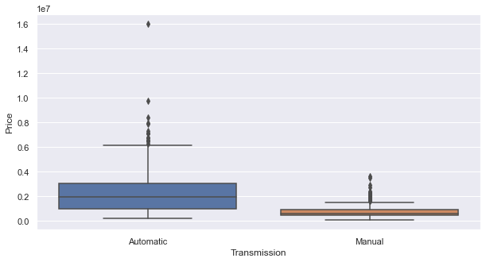

```python
plt.figure(figsize=(10, 5))
sns.boxplot(x="Transmission", y="Price", data=df)
```

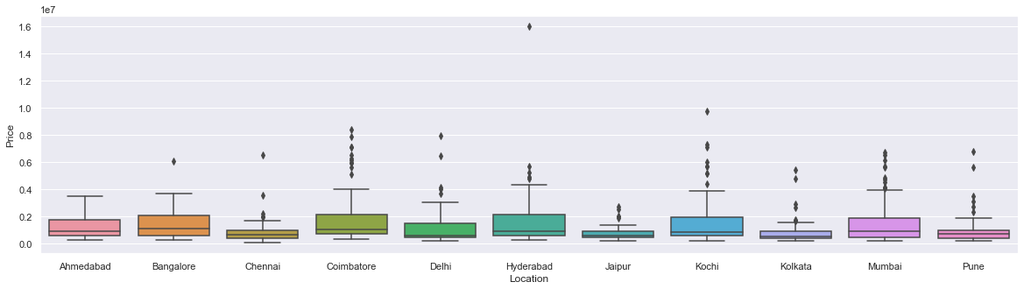

```python
plt.figure(figsize=(20, 5))
sns.boxplot(x="Location", y="Price", data=df)
```

- Ther is one outlier in Hydrabad market that skews the distribution signifiantly.

### Bivariate Analysis

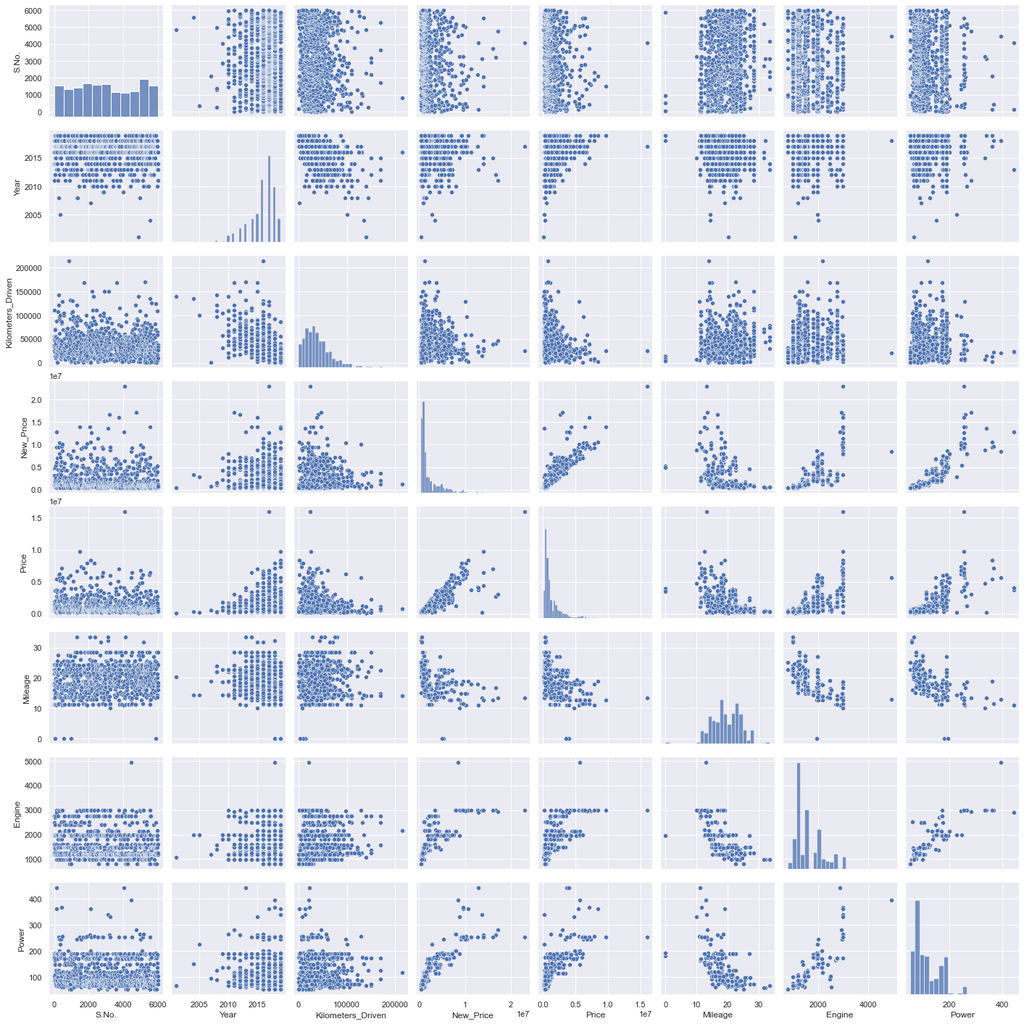

```python
sns.pairplot(df)
plt.show()
```

```python
# creating a 2-D Matrix with correlation plots
correlation = df.corr()
correlation
```

|  | S.No. | Year | Kilometers_Driven | New_Price | Price | Mileage | Engine | Power |
| --- | --- | --- | --- | --- | --- | --- | --- | --- |
| S.No. | 1.000000 | 0.007175 | -0.047169 | -0.073802 | -0.097758 | 0.123046 | -0.127056 | -0.108373 |
| Year | 0.007175 | 1.000000 | -0.520334 | -0.021393 | 0.227202 | -0.116559 | 0.016253 | -0.017271 |
| Kilometers_Driven | -0.047169 | -0.520334 | 1.000000 | -0.007603 | -0.154463 | 0.042783 | 0.129182 | 0.006821 |
| New_Price | -0.073802 | -0.021393 | -0.007603 | 1.000000 | 0.871899 | -0.378783 | 0.725188 | 0.871466 |
| Price | -0.097758 | 0.227202 | -0.154463 | 0.871899 | 1.000000 | -0.433571 | 0.696675 | 0.777187 |
| Mileage | 0.123046 | -0.116559 | 0.042783 | -0.378783 | -0.433571 | 1.000000 | -0.633602 | -0.540167 |
| Engine | -0.127056 | 0.016253 | 0.129182 | 0.725188 | 0.696675 | -0.633602 | 1.000000 | 0.853957 |
| Power | -0.108373 | -0.017271 | 0.006821 | 0.871466 | 0.777187 | -0.540167 | 0.853957 | 1.000000 |

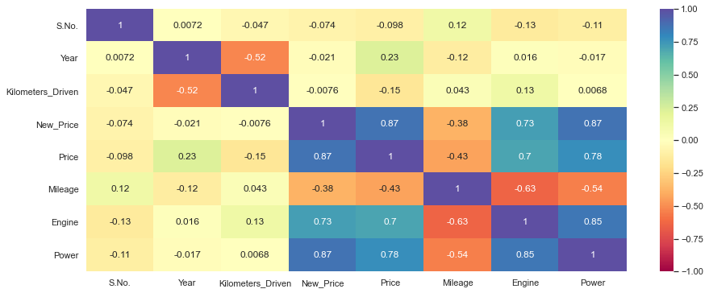

```python
plt.figure(figsize=(15, 6))
sns.heatmap(correlation, annot=True, vmin=-1, vmax=1, cmap="Spectral")
plt.show()
```

- Enigine and Mileage are negatively correlated.
- Price has strong positive correlation with new car price, Engine and Power.
- Engine and power are stongly correlated, so one of them can be elimiated from the model construction.
- Kilometer driven have negative impacton price.

## Outlier Treatment

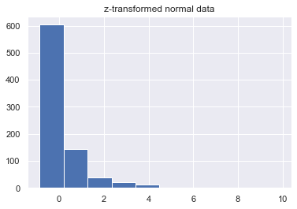

```python
def z_transform(x):
    return (x - np.mean(x)) / np.std(x)


plt.hist(z_transform(df["Price"]))
plt.title("z-transformed normal data")
plt.show()
```

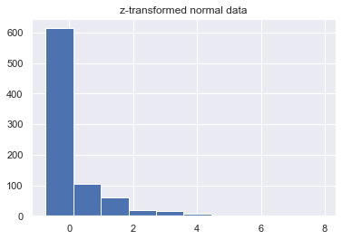

```python
def z_transform(x):
    return (x - np.mean(x)) / np.std(x)


plt.hist(z_transform(df["New_Price"]))
plt.title("z-transformed normal data")
plt.show()
```

```python
cols_to_log = ["Price", "New_Price"]

for colname in cols_to_log:
    df[colname + "_log"] = np.log(df[colname])

df.info()
```

```
<class 'pandas.core.frame.DataFrame'>
Int64Index: 823 entries, 2 to 6014
Data columns (total 18 columns):
 #   Column             Non-Null Count  Dtype
---  ------             --------------  -----
 0   S.No.              823 non-null    int64
 1   Location           823 non-null    category
 2   Year               823 non-null    int64
 3   Kilometers_Driven  823 non-null    int64
 4   Fuel_Type          823 non-null    category
 5   Transmission       823 non-null    category
 6   Owner_Type         823 non-null    category
 7   Seats              823 non-null    category
 8   New_Price          823 non-null    float64
 9   Price              823 non-null    float64
 10  Mileage            823 non-null    float64
 11  Engine             823 non-null    float64
 12  Power              823 non-null    float64
 13  Make               823 non-null    object
 14  Model              823 non-null    object
 15  Edition            823 non-null    object
 16  Price_log          823 non-null    float64
 17  New_Price_log      823 non-null    float64
dtypes: category(5), float64(7), int64(3), object(3)
memory usage: 127.3+ KB
```

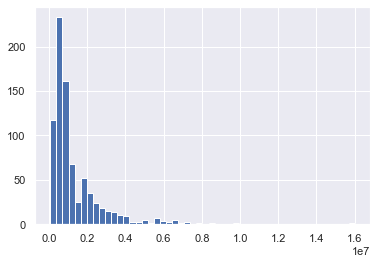

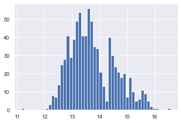

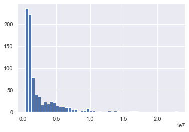

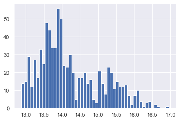

```python
plt.hist(df["Price"], 50)
plt.show()

plt.hist(df["Price_log"], 50)
plt.show()

plt.hist(df["New_Price"], 50)
plt.show()

plt.hist(df["New_Price_log"], 50)
plt.show()
```

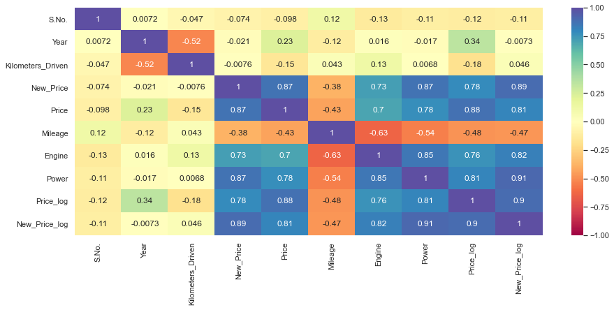

```python
# creating a 2-D Matrix with correlation plots
correlation = df.corr()
correlation

plt.figure(figsize=(15, 6))
sns.heatmap(correlation, annot=True, vmin=-1, vmax=1, cmap="Spectral")
plt.show()
```

## Model Building without outlier treatment - Best Model.

### Define dependent variable

```python
ind_vars = df.drop(
    [
        "S.No.",
        "Price",
        "Model",
        "Make",
        "Edition",
        "Transmission",
        "New_Price_log",
        "Price_log",
        "Location",
        "Owner_Type",
        "Seats",
        "Fuel_Type",
        "Power",
    ],
    axis=1,
)
dep_var = df[["Price"]]
```

```python
def encode_cat_vars(x):
    x = pd.get_dummies(
        x,
        columns=x.select_dtypes(include=["object", "category"]).columns.tolist(),
        drop_first=True,
    )
    return x


ind_vars_num = encode_cat_vars(ind_vars)
ind_vars_num.head()
```

|  | Year | Kilometers_Driven | New_Price | Mileage | Engine |
| --- | --- | --- | --- | --- | --- |
| 2 | 2011 | 46000 | 861000.0 | 18.20 | 1199.0 |
| 7 | 2016 | 36000 | 2100000.0 | 11.36 | 2755.0 |
| 10 | 2018 | 25692 | 1065000.0 | 21.56 | 1462.0 |
| 15 | 2014 | 110000 | 3201000.0 | 13.50 | 2477.0 |
| 20 | 2014 | 32982 | 4787000.0 | 22.69 | 1995.0 |

```python
ind_vars_num.shape
```

```
(823, 5)
```

### Split the data into train and test

```python
from sklearn.model_selection import train_test_split

x_train, x_test, y_train, y_test = train_test_split(
    ind_vars_num, dep_var, test_size=0.3, random_state=1
)
```

```python
print("Number of rows in train data =", x_train.shape[0])
print("Number of rows in train data =", x_test.shape[0])
```

```
Number of rows in train data = 576
Number of rows in train data = 247
```

```python
lin_reg_model = LinearRegression()
lin_reg_model.fit(x_train, y_train)
```

```
LinearRegression()
```

**Let us check the coefficients and intercept of the model, which are the parameters we learned.**

```python
coef_df = pd.DataFrame(
    np.append(lin_reg_model.coef_.flatten(), lin_reg_model.intercept_),
    index=x_train.columns.tolist() + ["Intercept"],
    columns=["Coefficients"],
)
coef_df
```

|  | Coefficients |
| --- | --- |
| Year | 1.436965e+05 |
| Kilometers_Driven | -2.339928e+00 |
| New_Price | 4.688915e-01 |
| Mileage | -1.678301e+04 |
| Engine | 2.151351e+02 |
| Intercept | -2.893191e+08 |

### Coefficient interpretations

- Coefficients of *year*, *new car price*, and *engine size* are positive.
  - Increase in these will lead to an increase in the price of an used car.
- Coefficients of *kilometer driven* and *mileage* are negative.
  - Increase in these will lead to a decrease in the price of an used car.

### Model performance check

- We will be using metric functions defined in sklearn for RMSE, MAE, and $R^2$.
- We will define a function to calculate adjusted $R^2$.
- We will create a function that will print out all the above metrics in one go.

```python
# Adjusted R^2
def adj_r2(ind_vars, targets, predictions):
    r2 = r2_score(targets, predictions)
    n = ind_vars.shape[0]
    k = ind_vars.shape[1]
    return 1 - ((1 - r2) * (n - 1) / (n - k - 1))


# Model performance check
def model_perf(model, inp, out):

    y_pred = model.predict(inp)
    y_act = out.values
    return pd.DataFrame(
        {
            "RMSE": np.sqrt(mean_squared_error(y_act, y_pred)),
            "MAE": mean_absolute_error(y_act, y_pred),
            "R^2": r2_score(y_act, y_pred),
            "Adjusted R^2": adj_r2(inp, y_act, y_pred),
        },
        index=[0],
    )
```

```python
# Checking model performance on train set
print("Training Performance\n")
print(model_perf(lin_reg_model, x_train, y_train))

# Checking model performance on test set
print("\n\nTest Performance\n")
print(model_perf(lin_reg_model, x_test, y_test))
```

```
Training Performance

            RMSE            MAE       R^2  Adjusted R^2
0  600353.814017  321914.762298  0.844637      0.843274


Test Performance

            RMSE            MAE       R^2  Adjusted R^2
0  642626.422679  317138.573376  0.787054      0.782636
```

**Observations**

- The train and test $R^2$ are 0.84 and 0.78, indicating that the model explains 84% and 78% of the total variation in the train and test sets respectively. Also, both scores are comparable.
- RMSE values on the train and test sets are also comparable.
- MAE indicates that our current model is able to predict used car price within a mean error of 317138.57 on the test set.

## Add-on: Forward Feature Selection

**Forward feature selection starts with an empty model and adds in variables one by one.**

- In each forward step, you add the one variable that gives the single best improvement to your model.
- We'll use forward feature selection on all the variables.

```python
from mlxtend.feature_selection import SequentialFeatureSelector as SFS

reg = LinearRegression()

fs_ind_vars = df.drop(
    [
        "S.No.",
        "Price",
        "Model",
        "Make",
        "Edition",
        "New_Price_log",
        "Price_log",
    ],
    axis=1,
)
fs_dep_var = df[["Price"]]

fs_ind_vars_num = encode_cat_vars(fs_ind_vars)
fs_ind_vars_num.head()

fs_x_train, fs_x_test, fs_y_train, fs_y_test = train_test_split(
    fs_ind_vars_num, fs_dep_var, test_size=0.3, random_state=1
)

# Build step forward feature selection
sfs = SFS(
    reg,
    k_features=fs_x_train.shape[1],
    forward=True,  # k_features denotes "Number of features to select"
    floating=False,
    scoring="r2",
    n_jobs=-1,
    verbose=2,
    cv=5,
)

# Perform SFFS
sfs = sfs.fit(fs_x_train, fs_y_train)
```

[output not shown]

[output cut: 50 more lines]

[output not shown]

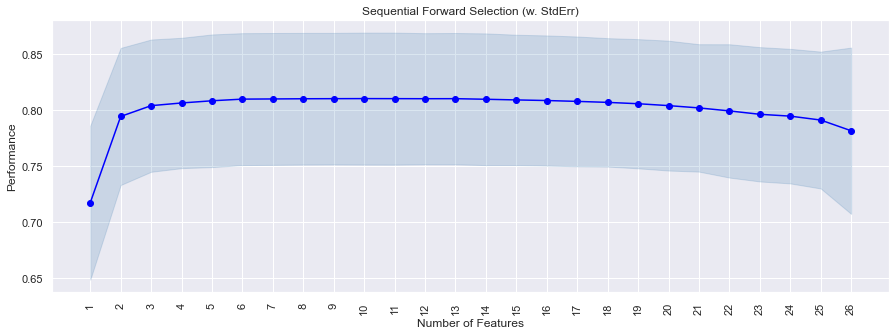

```python
# to plot the performance with addition of each feature
from mlxtend.plotting import plot_sequential_feature_selection as plot_sfs

fig1 = plot_sfs(sfs.get_metric_dict(), kind="std_err", figsize=(15, 5))
plt.title("Sequential Forward Selection (w. StdErr)")
plt.xticks(rotation=90)
plt.show()
```

```python
reg = LinearRegression()
# # Build step forward feature selection
sfs = SFS(
    reg,
    k_features=25,
    forward=True,
    floating=False,
    scoring="r2",
    n_jobs=-1,
    verbose=2,
    cv=5,
)

# Perform SFFS
sfs = sfs.fit(fs_x_train, fs_y_train)
```

[output not shown]

[output cut: 47 more lines]

[output not shown]

```python
# Let us select features which are important
feat_cols = list(sfs.k_feature_idx_)
print(feat_cols)
```

```
[0, 1, 2, 3, 4, 6, 7, 8, 9, 10, 11, 12, 13, 14, 15, 16, 17, 18, 19, 20, 21, 22, 23, 24, 25]
```

```python
fs_x_train.columns[feat_cols]
```

```
Index(['Year', 'Kilometers_Driven', 'New_Price', 'Mileage', 'Engine',
       'Location_Bangalore', 'Location_Chennai', 'Location_Coimbatore',
       'Location_Delhi', 'Location_Hyderabad', 'Location_Jaipur',
       'Location_Kochi', 'Location_Kolkata', 'Location_Mumbai',
       'Location_Pune', 'Fuel_Type_Diesel', 'Fuel_Type_Petrol',
       'Transmission_Manual', 'Owner_Type_Second', 'Owner_Type_Third',
       'Seats_4', 'Seats_5', 'Seats_6', 'Seats_7', 'Seats_8'],
      dtype='object')
```

## Obbservation.

- Year, Kilometer driven, new car price, mileage and Engine size plays significant role in pre owned price calculation.

## Model building with log based outlier treatment - least Favored model.s

```python
out_ind_vars = df.drop(
    [
        "S.No.",
        "Price",
        "Model",
        "Make",
        "Edition",
        "Transmission",
        "New_Price",
        "Price_log",
        "Location",
        "Owner_Type",
        "Seats",
        "Fuel_Type",
        "Power",
    ],
    axis=1,
)
out_dep_var = df[["Price"]]

out_ind_vars_num = encode_cat_vars(out_ind_vars)
out_ind_vars_num.head()
```

|  | Year | Kilometers_Driven | Mileage | Engine | New_Price_log |
| --- | --- | --- | --- | --- | --- |
| 2 | 2011 | 46000 | 18.20 | 1199.0 | 13.665850 |
| 7 | 2016 | 36000 | 11.36 | 2755.0 | 14.557448 |
| 10 | 2018 | 25692 | 21.56 | 1462.0 | 13.878485 |
| 15 | 2014 | 110000 | 13.50 | 2477.0 | 14.978974 |
| 20 | 2014 | 32982 | 22.69 | 1995.0 | 15.381414 |

```python
out_x_train, out_x_test, out_y_train, out_y_test = train_test_split(
    out_ind_vars_num, out_dep_var, test_size=0.3, random_state=1
)

out_lin_reg_model = LinearRegression()
out_lin_reg_model.fit(out_x_train, out_y_train)

coef_df = pd.DataFrame(
    np.append(out_lin_reg_model.coef_.flatten(), out_lin_reg_model.intercept_),
    index=out_x_train.columns.tolist() + ["Intercept"],
    columns=["Coefficients"],
)
print(coef_df)

# Checking model performance on train set
print("Training Performance\n")
print(model_perf(out_lin_reg_model, out_x_train, out_y_train))

# Checking model performance on test set
print("\n\nTest Performance\n")
print(model_perf(out_lin_reg_model, out_x_test, out_y_test))
```

```
                   Coefficients
Year               1.204256e+05
Kilometers_Driven -5.979988e+00
Mileage            9.975020e+02
Engine             2.980345e+02
New_Price_log      1.296394e+06
Intercept         -2.601084e+08
Training Performance

            RMSE            MAE       R^2  Adjusted R^2
0  816225.365789  493195.573468  0.712821      0.710302


Test Performance

            RMSE            MAE       R^2  Adjusted R^2
0  694709.204387  468686.505781  0.751138      0.745975
```

## Observation

- Log tansform has significant reduces the performance the model.

## Model building by removing one outlier - Second best model

```python
print(df.shape)
print(df.nlargest(30, "Price"))
df.drop(index=4079, axis=0, inplace=True)
print(df.shape)
print(df.nlargest(30, "Price"))
```

```
(823, 18)
      S.No.    Location  Year  Kilometers_Driven Fuel_Type Transmission  \
4079   4079   Hyderabad  2017              25000    Diesel    Automatic
1505   1505       Kochi  2019              26013    Diesel    Automatic
2095   2095  Coimbatore  2019               2526    Petrol    Automatic
1885   1885       Delhi  2018               6000    Diesel    Automatic
2319   2319  Coimbatore  2019               9312    Diesel    Automatic
1583   1583       Kochi  2019               6773    Diesel    Automatic
418     418  Coimbatore  2018              22397    Petrol    Automatic
1690   1690  Coimbatore  2018              40129    Diesel    Automatic
3752   3752       Kochi  2015              38467    Diesel    Automatic
5009   5009        Pune  2017              59500    Diesel    Automatic
1336   1336      Mumbai  2016              20002    Diesel    Automatic
4527   4527     Chennai  2016              29000    Diesel    Automatic
2808   2808      Mumbai  2017              19863    Diesel    Automatic
```

[output cut: 241 more lines]

```python
rm_ind_vars = df.drop(
    [
        "S.No.",
        "Price",
        "Model",
        "Make",
        "Edition",
        "Transmission",
        "New_Price_log",
        "Price_log",
        "Location",
        "Owner_Type",
        "Seats",
        "Fuel_Type",
        "Power",
    ],
    axis=1,
)

rm_dep_var = df[["Price"]]

rm_ind_vars_num = encode_cat_vars(rm_ind_vars)
rm_ind_vars_num.head()

rm_x_train, rm_x_test, rm_y_train, rm_y_test = train_test_split(
    rm_ind_vars_num, rm_dep_var, test_size=0.3, random_state=1
)

rm_lin_reg_model = LinearRegression()
rm_lin_reg_model.fit(rm_x_train, rm_y_train)

coef_df = pd.DataFrame(
    np.append(out_lin_reg_model.coef_.flatten(), rm_lin_reg_model.intercept_),
    index=rm_x_train.columns.tolist() + ["Intercept"],
    columns=["Coefficients"],
)
coef_df

# Checking model performance on train set
print("Training Performance\n")
print(model_perf(rm_lin_reg_model, rm_x_train, rm_y_train))

# Checking model performance on test set
print("\n\nTest Performance\n")
print(model_perf(rm_lin_reg_model, rm_x_test, rm_y_test))
```

```
Training Performance

            RMSE            MAE       R^2  Adjusted R^2
0  626058.701521  333261.470682  0.809068       0.80739


Test Performance

            RMSE           MAE       R^2  Adjusted R^2
0  482163.741223  301611.66506  0.862798      0.859951
```

### Observations

- Removing just one outlier has a significant impace on the testing and training perfomance.
- $R^2$ has improved significantly for testing data.
- MAE has decreased to 301611.66.
- It is not wise to delete the outlier with out discussing with data owners.
- So though this model performs better, beacuse of lack of context this is second best model.